# Cyclistic Bike-share case study

Subasree

2022-04-24

## Loading the necessary packages

```r
library(tidyverse)
library(dplyr)
library(lubridate)
library(janitor)
```

```r
library(ggplot2)
library(geosphere)
```

## Reading the datasets in the csv files to dataframes

```r
Apr_2021_df <- read.csv("Bikeshare_casestudy_202104_divvy_tripdata.csv")
May_2021_df <- read.csv("Bikeshare_casestudy_202105_divvy_tripdata.csv")
Jun_2021_df <- read.csv("Bikeshare_casestudy_202106_divvy_trip_data.csv")
Jul_2021_df <- read.csv("Bikeshare_casestudy_202107_divvy_trip_data.csv")
Aug_2021_df <- read.csv("Bikeshare_casestudy_202108_divvy_tripdata.csv")
Sep_2021_df <- read.csv("Bikeshare_casestudy_202109_divvy_trip_data.csv")
Oct_2021_df <- read.csv("Bikeshare_casestudy_202110_divvy_tripdata.csv")
Nov_2021_df <- read.csv("Bikeshare_casestudy_202111_divvy_tripdata.csv")
Dec_2021_df <- read.csv("Bikeshare_casestudy_202112_divvy_tripdata.csv")
Jan_2022_df <- read.csv("Bikeshare_casestudy_202201_divvy_tripdata.csv")
Feb_2022_df <- read.csv("Bikeshare_casestudy_202202_divvy_tripdata.csv")
Mar_2022_df <- read.csv("Bikeshare_casestudy_202203_divvy_tripdata.csv")
```

## Binding the dataframes by rows

```r
#Bind all the twelve data sets to a data frame
bikeshare_df <- bind_rows(Apr_2021_df,May_2021_df,Jun_2021_df,Jul_2021_df,
                          Aug_2021_df,Sep_2021_df,Oct_2021_df,Nov_2021_df,
                          Dec_2021_df,Jan_2022_df,Feb_2022_df,Mar_2022_df)

#View the data frame(bikeshare_df)

View(bikeshare_df)
```

## Cleaning the data

The columns names are verified and the names that are inappropiate are renamed.

```r
#Checking and renaming the column names

colnames(bikeshare_df)
```

```
##  [1] "ride_id"            "rideable_type"      "started_at"
##  [4] "ended_at"           "start_station_name" "start_station_id"
##  [7] "end_station_name"   "end_station_id"     "start_lat"
## [10] "start_lng"          "end_lat"            "end_lng"
## [13] "member_casual"
```

```r
bikeshare_df <- rename(bikeshare_df,Customer_type = member_casual)
colnames(bikeshare_df)
```

```
##  [1] "ride_id"            "rideable_type"      "started_at"
##  [4] "ended_at"           "start_station_name" "start_station_id"
##  [7] "end_station_name"   "end_station_id"     "start_lat"
## [10] "start_lng"          "end_lat"            "end_lng"
## [13] "Customer_type"
```

```r
bikeshare_df <- rename(bikeshare_df,c(Start_dateTime = started_at,End_dateTime = ended_at))

bikeshare_df <- clean_names(bikeshare_df)

colnames(bikeshare_df)
```

```
##  [1] "ride_id"            "rideable_type"      "start_date_time"
##  [4] "end_date_time"      "start_station_name" "start_station_id"
##  [7] "end_station_name"   "end_station_id"     "start_lat"
## [10] "start_lng"          "end_lat"            "end_lng"
## [13] "customer_type"
```

```r
#Removing the columns and rows that are entirely empty

bikeshare_df <- remove_empty(bikeshare_df,which = c("rows","cols"))
```

```r
#Taking only the distinct values

bikeshare_df <- distinct(bikeshare_df)
```

```r
#Description of the dataframe

str(bikeshare_df)
```

```
## 'data.frame':    4606 obs. of  13 variables:
##  $ ride_id           : chr  "CCC0180543DFECBC" "218845F447614D13" "0C558C61346C0E37" "F31124732D761A39" ...
##  $ rideable_type     : chr  "classic_bike" "electric_bike" "classic_bike" "classic_bike" ...
##  $ start_date_time   : chr  "4/4/2021 12:27" "4/25/2021 15:48" "4/11/2021 1:31" "4/11/2021 15:08" ...
##  $ end_date_time     : chr  "4/4/2021 13:33" "4/25/2021 16:05" "4/11/2021 1:55" "4/11/2021 15:22" ...
##  $ start_station_name: chr  "Albany Ave & Bloomingdale Ave" "California Ave & Milwaukee Ave" "Morgan St & Lake St" "Lake Park Ave & 56th St" ...
##  $ start_station_id  : chr  "15655" "13084" "TA1306000015" "TA1309000063" ...
##  $ end_station_name  : chr  "Clifton Ave & Armitage Ave" "Sheffield Ave & Kingsbury St" "Milwaukee Ave & Wabansia Ave" "Greenwood Ave & 47th St" ...
##  $ end_station_id    : chr  "TA1307000163" "13154" "13243" "TA1308000002" ...
##  $ start_lat         : num  41.9 41.9 41.9 41.8 41.9 ...
##  $ start_lng         : num  -87.7 -87.7 -87.7 -87.6 -87.7 ...
##  $ end_lat           : num  41.9 41.9 41.9 41.8 41.9 ...
##  $ end_lng           : num  -87.7 -87.7 -87.7 -87.6 -87.6 ...
##  $ customer_type     : chr  "member" "member" "member" "casual" ...
```

```r
#Changing the datatype of the start and end time to DateTime

start_factor <- as.factor(bikeshare_df$start_date_time)
end_factor <- as.factor(bikeshare_df$end_date_time)

bikeshare_df$start_date_time <- strptime(start_factor,format = "%m/%d/%Y %H:%M")
bikeshare_df$end_date_time <- strptime(end_factor,format = "%m/%d/%Y %H:%M")
```

```r
#Calculating the total duration in Minutes and adding the column to the dataframe

total_duration_in_mins <- difftime(bikeshare_df$end_date_time,bikeshare_df$start_date_time)

total_duration_in_mins <- (as.numeric(total_duration_in_mins))/60

bikeshare_df <- mutate(bikeshare_df,total_duration_in_mins)
```

```r
#Removing the bad data with negative duration values

bikeshare_df <- bikeshare_df[!(bikeshare_df$total_duration_in_mins < 0),]
```

```r
#Replacing the incorrect customer types

bikeshare_df$customer_type <- recode(bikeshare_df$customer_type,"Subscriber" = "member",
                                        "Customer" = "casual")
```

```r
#Taking the start and end dates and adding to dataframes

start_date <- as.Date(bikeshare_df$start_date_time,format = "%Y-%m-%d")
end_date <- as.Date(bikeshare_df$end_date_time,format = "%Y-%m-%d")

bikeshare_df <- mutate(bikeshare_df,start_date,end_date)
```

```r
#Taking the month, year and week details for visualizing

time_Period <- format(start_date,"%Y-%m")

bikeshare_df <- mutate(bikeshare_df,time_Period)

days_of_week <- wday(start_date, label = TRUE)

bikeshare_df <- mutate(bikeshare_df,days_of_week)
```

```r
#Sorting in ascending order by date
bikeshare_df <- arrange(bikeshare_df,start_date)
```

## Descriptive analysis

```r
#calculating the distance covered by start and end, latitude and longitude values

bikeshare_df <- bikeshare_df %>% mutate(ride_length = round(distHaversine(cbind(start_lng,start_lat),cbind(end_lng,end_lat)),2))

#Calculating the average ride distance covered by the customers by months

Average_ride_1 <-  bikeshare_df %>% group_by(customer_type,time_Period) %>% drop_na() %>% summarise(Average_ride_length = mean(ride_length))
#Calculating the average ride distance covered by the customers by days of the week

Average_ride_2 <-  bikeshare_df %>% group_by(customer_type,days_of_week) %>% drop_na() %>% summarise(Average_ride_length = mean(ride_length))
#calculating the average time duration by months

Average_ride <- bikeshare_df %>% group_by(customer_type,time_Period) %>% drop_na() %>% summarise(Average_time_taken = mean(total_duration_in_mins))
#calculate the Total and maximum number of minutes by both customers over the year

total_mins <- bikeshare_df %>% group_by(customer_type,time_Period) %>% drop_na() %>% summarise(sum(total_duration_in_mins))
max_mins <- bikeshare_df %>% group_by(customer_type,time_Period) %>% drop_na() %>% summarise(max(total_duration_in_mins))
mini_mins <- bikeshare_df %>% group_by(customer_type,time_Period) %>% drop_na() %>% summarise(min(total_duration_in_mins))
View(max_mins)
View(total_mins)
View(mini_mins)
```

## Visualizing the data

After cleaning, adding new columns and analyzing the dataframe, visualizing the data by using ggplot2 library

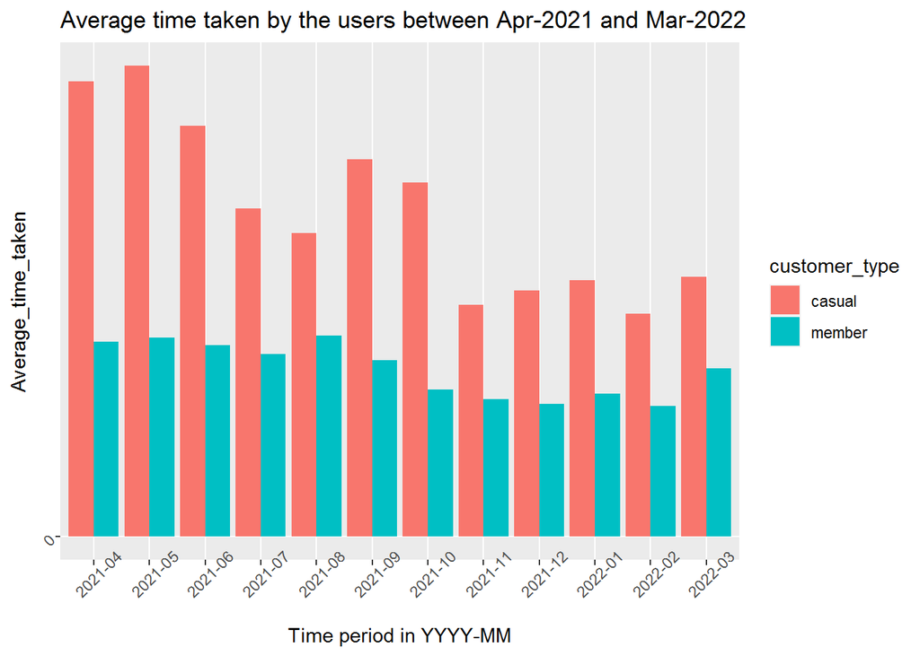

```r
#visualizing the Average time period used by both the customer types

ggplot(data = Average_ride,aes(x= time_Period,y= Average_time_taken,fill = customer_type))+
  geom_bar(position = "dodge",stat="identity")+
  scale_y_continuous(breaks = c(0,50,100,150,200,250,300,350,400))+
  theme(axis.text = element_text(angle = 45))+
  labs(x= "Time period in YYYY-MM",
       title = "Average time taken by the users between Apr-2021 and Mar-2022")
```

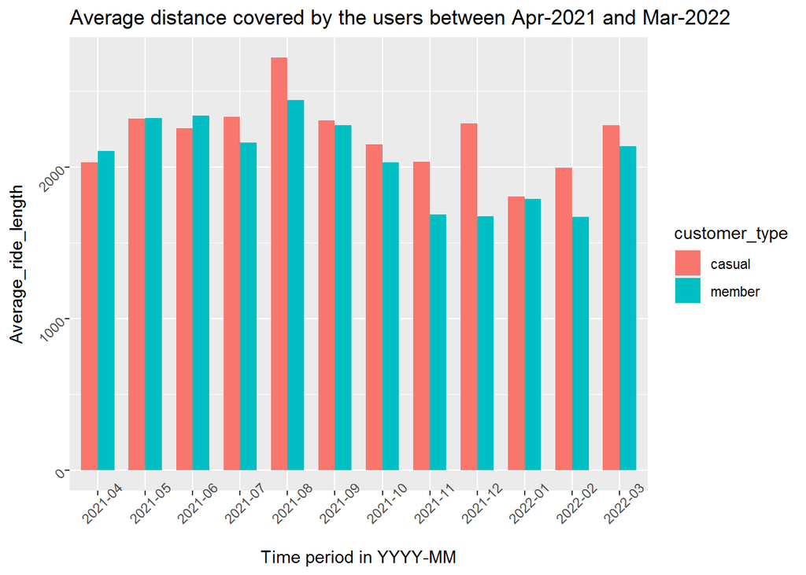

```r
#visualizing the Average distance for each month by customer types

Average_ride_1 %>% ggplot()+
  geom_bar(aes(x= time_Period, y= Average_ride_length, fill=customer_type),position= "dodge",   stat="identity",width = 0.7) +
  theme(axis.text = element_text(angle = 45))+
  labs(x= "Time period in YYYY-MM", y = "Average_ride_length",
       title = "Average distance covered by the users between Apr-2021 and Mar-2022")
```

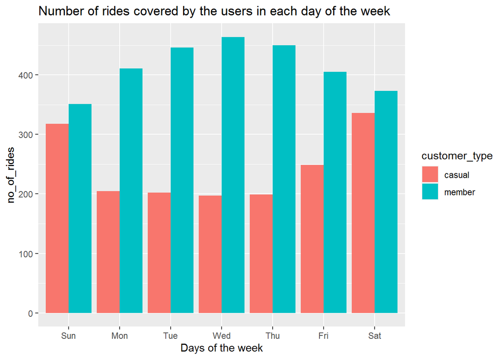

```r
##Visualizing the rides covered by days of the week

bikeshare_df %>% group_by(customer_type,days_of_week) %>%
  summarise(number_of_rides = n(),Average_ride_duration = mean(total_duration_in_mins)) %>%
  arrange(customer_type,days_of_week) %>%
  ggplot(aes(x= days_of_week,y= number_of_rides,fill= customer_type))+
  geom_bar(position = "dodge",stat= "identity")+
  labs(x= "Days of the week", y = "no_of_rides",
       title = "Number of rides covered by the users in each day of the week")
```

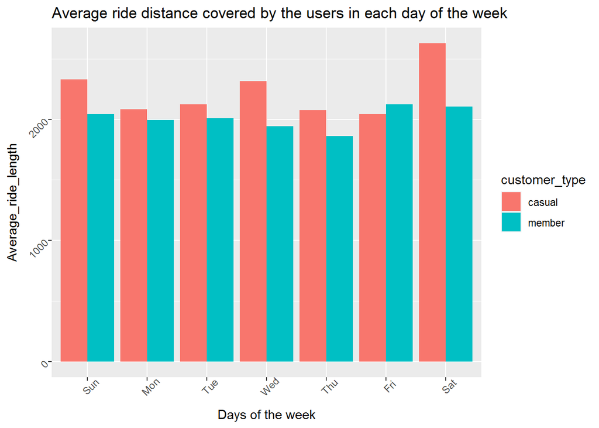

```r
#Visualizing the average ride distance covered by days of the week

ggplot(data = Average_ride_2, aes(x= days_of_week,y= Average_ride_length,fill= customer_type))+
  geom_bar(position = "dodge", stat = "identity")+
  theme(axis.text = element_text(angle = 45))+
  labs(x= "Days of the week",
       title = "Average ride distance covered by the users in each day of the week")
```

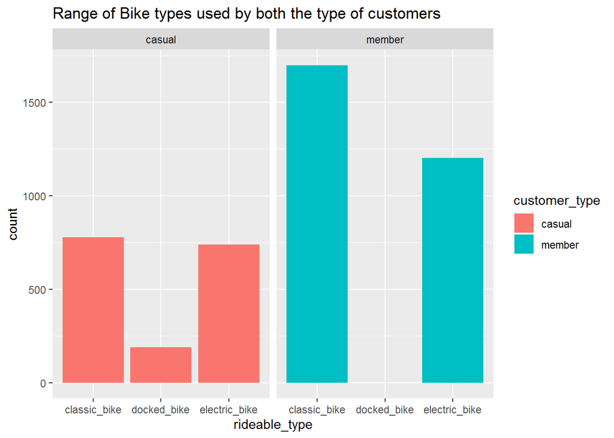

```r
#visualizing the different riding type used by both the customers

ggplot(data = bikeshare_df,aes(x= rideable_type, fill = customer_type))+geom_bar()+
  facet_wrap(~customer_type)+
  labs(title = "Range of Bike types used by both the type of customers")
```

## Key findings

- By comparing the average duration taken by both the type of customers between April 2021 and March 2022, we can see that the time period taken by the casuals are greater than the members.
- We can suggest from the findings that the casuals spend more time with the bikes than the members.
- By comparing the number of rides by days of the week, it is seen that the casuals are present more in weekends than the weekdays.
- The average ride distance for the weekends is more for the casuals than the weekdays. This suggest that the members are more of working professionals and casuals use bikes for entertainment and other non-consistent activities.
- It is also seen that while the casuals increase on weekends, the range of the members is almost the same throughout the week.
- The bike types that casuals use more are the classic and electric bike but the docked bike is used more by casuals than of the members.